# Tugas Praktikum 4

## Karakteristik MA(2)

### Plot Time Series

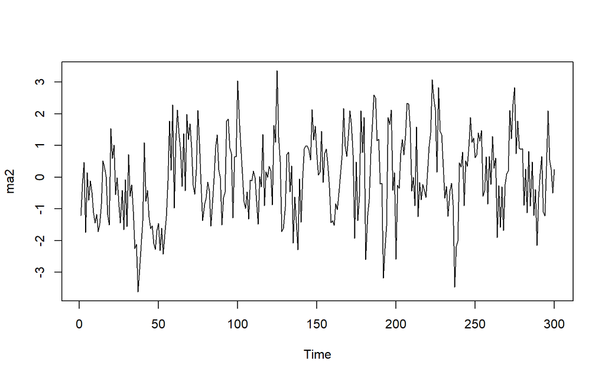

```r
ts.plot(ma2)
```

Berdasarkan plot time series, terlihat bahwa data MA(2) yang dibangkitkan stasioner dalam rataan

### Plot ACF

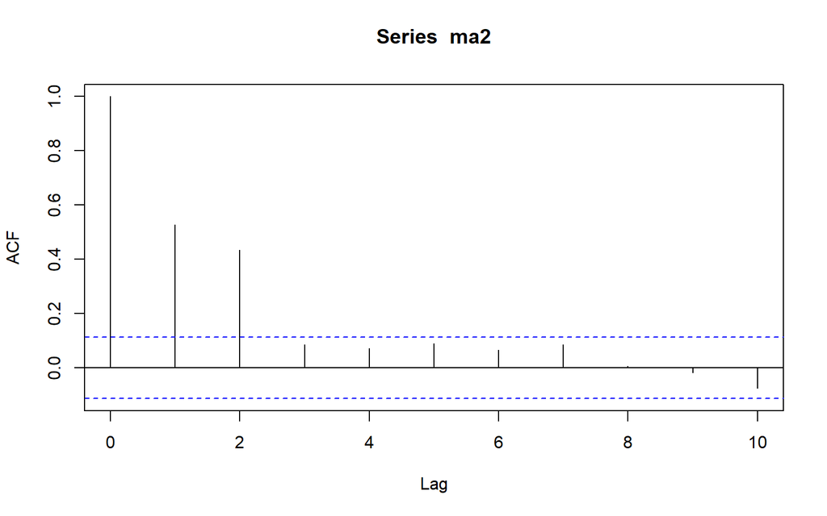

```r
acf(ma2,lag.max = 10)
```

Berdasarkan plot ACF, terlihat bahwa ACF cut off pada lag 1 dan lag 2, hanya lag 1 dan 2 yang signifikan, sedangkan autokorelasi untuk lag > 2 mendekati nol.

### Plot PACF

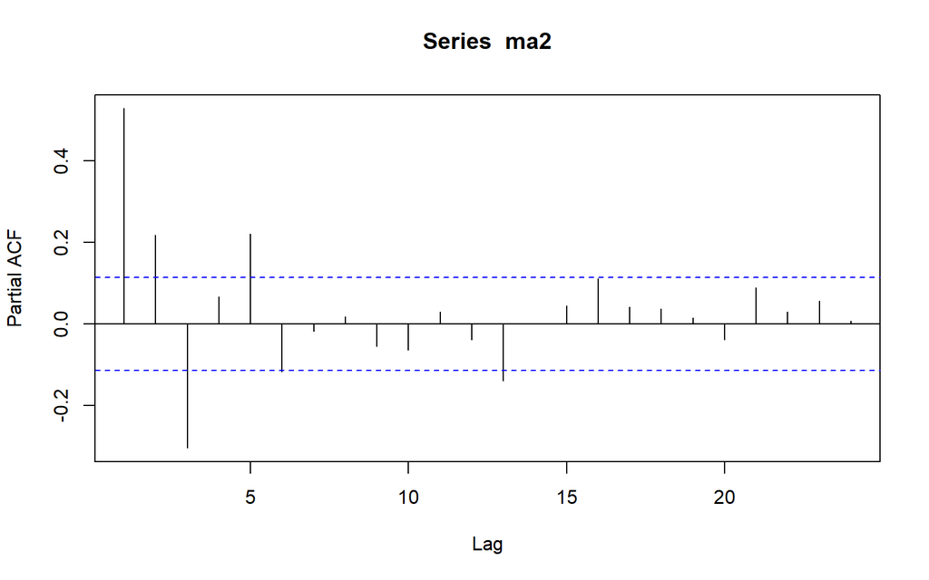

```r
pacf(ma2)
```

Berdasarkan plot PACF tersebut, terlihat bahwa plot PACF cenderung *tails off* dan membentuk gelombang sinus.

### Plot EACF

```r
TSA::eacf(ma2)
```

```
## AR/MA
##   0 1 2 3 4 5 6 7 8 9 10 11 12 13
## 0 x x o o o o o o o o o  o  x  x
## 1 x x x o o o o o o o o  o  o  o
## 2 x x x x o o o o o o o  o  o  o
## 3 x x x x x o o o o o o  o  o  o
## 4 x x x x x o o o o o o  o  o  o
## 5 x x o x x o x o o o o  o  o  o
## 6 x x x o x o o x o o o  o  o  o
## 7 x o x o x o o x o o o  o  o  o
```

Berdasarkan pola segitiga nol pada plot EACF, terlihat bahwa segitiga nol berada pada ordo AR(0) dan ordo MA(2).

## Scatterplot Antar Lag

### Korelasi antara $Y_t$ dengan $Y_{t-1}$

```r
#Yt
yt_ma2 <- ma2[-1]
yt_ma2
```

```
##   [1] -0.205397058  0.471173424 -1.745463687  0.141510314 -0.729712854
##   [6] -0.114842790 -0.472894305 -1.127948717 -1.443797742 -1.171879031
##  [11] -1.723286222 -1.461924092 -0.845074607  0.519525249  0.312187420
##  [16]  0.020572732 -1.181770516 -1.508255550  1.534249256  0.598119283
##  [21]  1.012450498 -0.556369299 -0.011041246 -0.774213194 -1.449939345
##  [26] -0.420758391 -1.662676381 -0.079747157 -1.556197355  0.718835126
##  [31] -0.596243221 -0.238298741 -1.070389923 -2.255260716 -2.120011486
##  [36] -3.624543435 -2.913580609 -2.138714925 -1.388210999  1.086560934
##  [41] -0.768382742 -0.413123964 -1.263954490 -1.619808057 -1.534624150
##  [46] -2.091327966 -2.276021753 -1.689013389 -1.457572736 -2.319068111
##  [51] -1.602598402 -2.425338748 -1.807763414 -1.233628102 -0.110845196
##  [56]  1.775654086  0.223607057  2.285258743 -0.979456751  1.157010823
##  [61]  2.116941328  1.378789117  0.845856907 -0.296314421  1.372262398
##  [66] -0.432336811  1.978634754  1.193531021  1.688995021  0.939220832
##  [71] -0.250827924 -0.544575725  0.228395751  2.109671129  1.063681873
```

[output cut: 45 more lines]

```r
#Yt-1
yt_1_ma2 <- ma2[-n]
yt_1_ma2
```

```
##   [1] -1.207065749 -0.205397058  0.471173424 -1.745463687  0.141510314
##   [6] -0.729712854 -0.114842790 -0.472894305 -1.127948717 -1.443797742
##  [11] -1.171879031 -1.723286222 -1.461924092 -0.845074607  0.519525249
##  [16]  0.312187420  0.020572732 -1.181770516 -1.508255550  1.534249256
##  [21]  0.598119283  1.012450498 -0.556369299 -0.011041246 -0.774213194
##  [26] -1.449939345 -0.420758391 -1.662676381 -0.079747157 -1.556197355
##  [31]  0.718835126 -0.596243221 -0.238298741 -1.070389923 -2.255260716
##  [36] -2.120011486 -3.624543435 -2.913580609 -2.138714925 -1.388210999
##  [41]  1.086560934 -0.768382742 -0.413123964 -1.263954490 -1.619808057
##  [46] -1.534624150 -2.091327966 -2.276021753 -1.689013389 -1.457572736
##  [51] -2.319068111 -1.602598402 -2.425338748 -1.807763414 -1.233628102
##  [56] -0.110845196  1.775654086  0.223607057  2.285258743 -0.979456751
##  [61]  1.157010823  2.116941328  1.378789117  0.845856907 -0.296314421
##  [66]  1.372262398 -0.432336811  1.978634754  1.193531021  1.688995021
##  [71]  0.939220832 -0.250827924 -0.544575725  0.228395751  2.109671129
```

[output cut: 45 more lines]

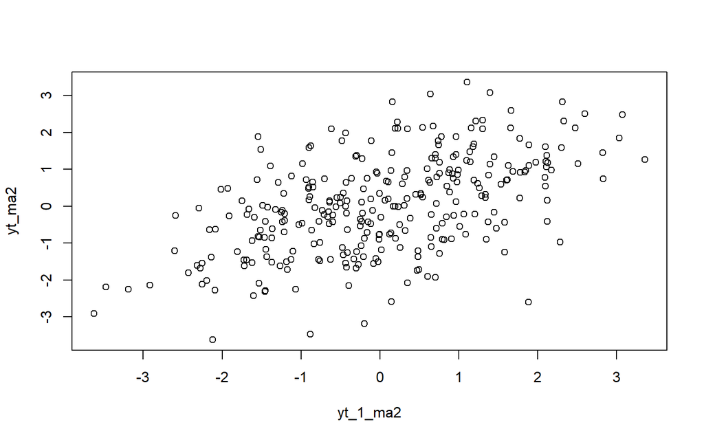

```r
plot(y=yt_ma2,x=yt_1_ma2)
```

Berdasarkan scatterplot tersebut, terlihat bahwa terdapat hubungan positif antara $Y_t$ dengan $Y_{t-1}$. Hal ini sesuai dengan teori yang ada

```r
cor(yt_ma2,yt_1_ma2)
```

```
## [1] 0.5282201
```

Korelasi antara $Y_t$ dengan $Y_{t-1}$ dari hasil simulasi mendekati perhitungan teoritis yaitu

$$\rho_1 = \frac{0.4 + 0.4 \times 0.6}{1 + (-0.4)^2 + (-0.6)^2}
= \frac{0.64}{1.52}
= 0.4210526$$

### Korelasi antara $Y_t$ dengan $Y_{t-2}$

```r
#Yt
yt_ma2 <- ma2[-c(1,2)]
yt_ma2
```

```
##   [1]  0.471173424 -1.745463687  0.141510314 -0.729712854 -0.114842790
##   [6] -0.472894305 -1.127948717 -1.443797742 -1.171879031 -1.723286222
##  [11] -1.461924092 -0.845074607  0.519525249  0.312187420  0.020572732
##  [16] -1.181770516 -1.508255550  1.534249256  0.598119283  1.012450498
##  [21] -0.556369299 -0.011041246 -0.774213194 -1.449939345 -0.420758391
##  [26] -1.662676381 -0.079747157 -1.556197355  0.718835126 -0.596243221
##  [31] -0.238298741 -1.070389923 -2.255260716 -2.120011486 -3.624543435
##  [36] -2.913580609 -2.138714925 -1.388210999  1.086560934 -0.768382742
##  [41] -0.413123964 -1.263954490 -1.619808057 -1.534624150 -2.091327966
##  [46] -2.276021753 -1.689013389 -1.457572736 -2.319068111 -1.602598402
##  [51] -2.425338748 -1.807763414 -1.233628102 -0.110845196  1.775654086
##  [56]  0.223607057  2.285258743 -0.979456751  1.157010823  2.116941328
##  [61]  1.378789117  0.845856907 -0.296314421  1.372262398 -0.432336811
##  [66]  1.978634754  1.193531021  1.688995021  0.939220832 -0.250827924
##  [71] -0.544575725  0.228395751  2.109671129  1.063681873 -0.209897795
```

[output cut: 45 more lines]

```r
#Yt-2
yt_2_ma2 <- ma2[-c(299,n)]
yt_2_ma2
```

```
##   [1] -1.207065749 -0.205397058  0.471173424 -1.745463687  0.141510314
##   [6] -0.729712854 -0.114842790 -0.472894305 -1.127948717 -1.443797742
##  [11] -1.171879031 -1.723286222 -1.461924092 -0.845074607  0.519525249
##  [16]  0.312187420  0.020572732 -1.181770516 -1.508255550  1.534249256
##  [21]  0.598119283  1.012450498 -0.556369299 -0.011041246 -0.774213194
##  [26] -1.449939345 -0.420758391 -1.662676381 -0.079747157 -1.556197355
##  [31]  0.718835126 -0.596243221 -0.238298741 -1.070389923 -2.255260716
##  [36] -2.120011486 -3.624543435 -2.913580609 -2.138714925 -1.388210999
##  [41]  1.086560934 -0.768382742 -0.413123964 -1.263954490 -1.619808057
##  [46] -1.534624150 -2.091327966 -2.276021753 -1.689013389 -1.457572736
##  [51] -2.319068111 -1.602598402 -2.425338748 -1.807763414 -1.233628102
##  [56] -0.110845196  1.775654086  0.223607057  2.285258743 -0.979456751
##  [61]  1.157010823  2.116941328  1.378789117  0.845856907 -0.296314421
##  [66]  1.372262398 -0.432336811  1.978634754  1.193531021  1.688995021
##  [71]  0.939220832 -0.250827924 -0.544575725  0.228395751  2.109671129
```

[output cut: 45 more lines]

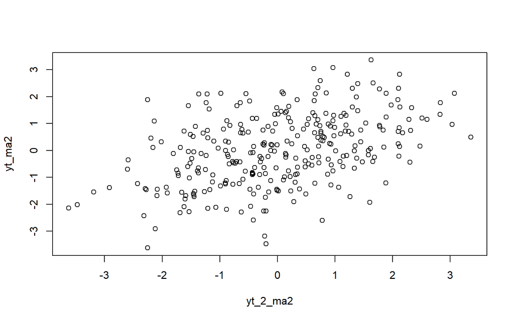

```r
plot(y=yt_ma2,x=yt_2_ma2)
```

```r
cor(yt_ma2,yt_2_ma2)
```

```
## [1] 0.4356204
```

Korelasi antara $Y_t$ dengan $Y_{t-2}$ dari hasil simulasi mendekati perhitungan teoritis berikut:

$$\rho_2 = \frac{\theta_2}{1 + \theta_1^2 + \theta_2^2}
= \frac{0.6}{1 + 0.4^2 + 0.6^2}
= \frac{0.6}{1.52}
= 0.3947$$

### Korelasi antara $Y_t$ dengan $Y_{t-3}$

```r
#Yt
yt_ma2 <- ma2[-c(1,2,3)]
yt_ma2
```

```
##   [1] -1.745463687  0.141510314 -0.729712854 -0.114842790 -0.472894305
##   [6] -1.127948717 -1.443797742 -1.171879031 -1.723286222 -1.461924092
##  [11] -0.845074607  0.519525249  0.312187420  0.020572732 -1.181770516
##  [16] -1.508255550  1.534249256  0.598119283  1.012450498 -0.556369299
##  [21] -0.011041246 -0.774213194 -1.449939345 -0.420758391 -1.662676381
##  [26] -0.079747157 -1.556197355  0.718835126 -0.596243221 -0.238298741
##  [31] -1.070389923 -2.255260716 -2.120011486 -3.624543435 -2.913580609
##  [36] -2.138714925 -1.388210999  1.086560934 -0.768382742 -0.413123964
##  [41] -1.263954490 -1.619808057 -1.534624150 -2.091327966 -2.276021753
##  [46] -1.689013389 -1.457572736 -2.319068111 -1.602598402 -2.425338748
##  [51] -1.807763414 -1.233628102 -0.110845196  1.775654086  0.223607057
##  [56]  2.285258743 -0.979456751  1.157010823  2.116941328  1.378789117
##  [61]  0.845856907 -0.296314421  1.372262398 -0.432336811  1.978634754
##  [66]  1.193531021  1.688995021  0.939220832 -0.250827924 -0.544575725
##  [71]  0.228395751  2.109671129  1.063681873 -0.209897795 -1.371901203
```

[output cut: 45 more lines]

```r
#Yt-3
yt_3_ma2 <- ma2[-c(298,299,n)]
yt_3_ma2
```

```
##   [1] -1.207065749 -0.205397058  0.471173424 -1.745463687  0.141510314
##   [6] -0.729712854 -0.114842790 -0.472894305 -1.127948717 -1.443797742
##  [11] -1.171879031 -1.723286222 -1.461924092 -0.845074607  0.519525249
##  [16]  0.312187420  0.020572732 -1.181770516 -1.508255550  1.534249256
##  [21]  0.598119283  1.012450498 -0.556369299 -0.011041246 -0.774213194
##  [26] -1.449939345 -0.420758391 -1.662676381 -0.079747157 -1.556197355
##  [31]  0.718835126 -0.596243221 -0.238298741 -1.070389923 -2.255260716
##  [36] -2.120011486 -3.624543435 -2.913580609 -2.138714925 -1.388210999
##  [41]  1.086560934 -0.768382742 -0.413123964 -1.263954490 -1.619808057
##  [46] -1.534624150 -2.091327966 -2.276021753 -1.689013389 -1.457572736
##  [51] -2.319068111 -1.602598402 -2.425338748 -1.807763414 -1.233628102
##  [56] -0.110845196  1.775654086  0.223607057  2.285258743 -0.979456751
##  [61]  1.157010823  2.116941328  1.378789117  0.845856907 -0.296314421
##  [66]  1.372262398 -0.432336811  1.978634754  1.193531021  1.688995021
##  [71]  0.939220832 -0.250827924 -0.544575725  0.228395751  2.109671129
```

[output cut: 45 more lines]

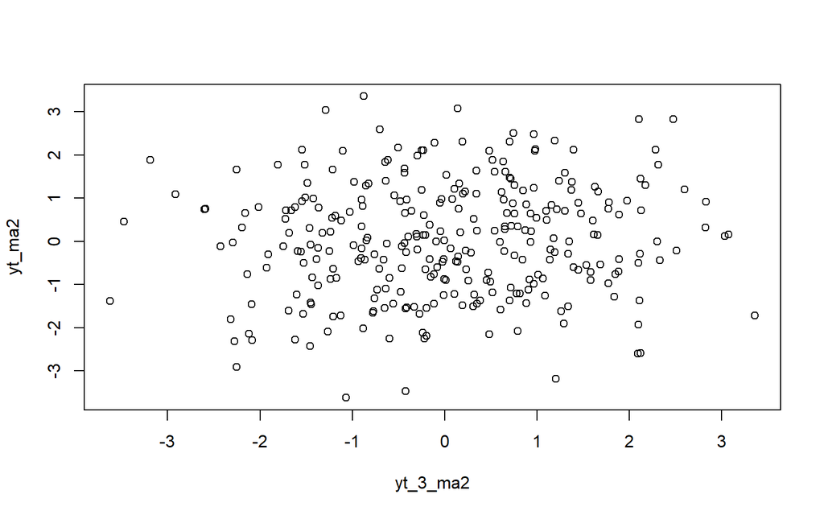

```r
plot(y=yt_ma2,x=yt_3_ma2)
```

```r
cor(yt_ma2,yt_3_ma2)
```

```
## [1] 0.08544546
```

## Autokorelasi

```r
acf(ma2,lag.max = 10, plot=FALSE)$acf
```

```
## , , 1
##
##               [,1]
##  [1,]  1.000000000
##  [2,]  0.527403800
##  [3,]  0.434811378
##  [4,]  0.085266051
##  [5,]  0.071480314
##  [6,]  0.089653347
##  [7,]  0.065180718
##  [8,]  0.084758297
##  [9,]  0.005668758
## [10,] -0.017171527
## [11,] -0.075594452
```

```r
acf(ma2_sim,lag.max = 10, plot=FALSE)$acf
```

```
## , , 1
##
##              [,1]
##  [1,]  1.00000000
##  [2,]  0.47473144
##  [3,]  0.35949296
##  [4,] -0.03608089
##  [5,] -0.07858146
##  [6,] -0.12418465
##  [7,] -0.11834565
##  [8,] -0.07421307
##  [9,] -0.01706904
## [10,]  0.03801561
## [11,]  0.05844698
```

# Proses AR(2)

## Pembangkitan Proses AR dengan $\phi_{1} = 0.5$ dan $\phi_{2} = 0.2$

Akan dicoba membangkitkan AR(2) dengan $\phi_{1} = 0.5$ dan $\phi_{2} = 0.2$ sebanyak 300 observasi.

```r
set.seed(1234)
n <- 300
ar2 <- rep(0, n)
ar2[1:2] <- wn[1:2]
```

Nilai-nilai selanjutnya dapat dicari melalui *loop*. Bentuk loop dapat dilihat dari rumus AR(2) yang hendak dibangkitkan:

$$Y_t = e_t+0.5Y_{t-1}+0.2Y_{t-2}$$

```r
for(i in 3:n){
  ar2[i] <- 0.5*ar2[i-1] + 0.2*ar2[i-2] + wn[i]
}
ar2
```

```
##   [1] -1.207065749  0.277429242  0.981742648 -1.799340530 -0.274197047
##   [6]  0.009089263 -0.625034738 -0.857331372 -1.118124633 -1.620566420
##  [11] -1.511100836 -2.078050147 -2.117499135 -1.409900780 -0.168956158
##  [16] -0.476743729 -0.783172602 -1.398130464 -1.692871432  1.289773370
##  [21]  0.440400618 -0.012530914 -0.358733205  0.277716656 -0.626608560
##  [26] -1.705965859 -0.403548921 -1.566623355 -0.879159762 -1.688853153
##  [31]  0.082039017 -0.772344201 -1.079204335 -1.195329068 -2.442598870
##  [36] -2.627984511 -3.982551678 -3.857865933 -3.019737161 -2.747339308
##  [41] -0.528120821 -1.882170996 -1.902074296 -1.608094349 -2.178802110
##  [46] -2.379534243 -2.732845736 -3.094315602 -2.617555067 -2.424490611
##  [51] -3.541787576 -2.837867835 -3.236181057 -3.200626105 -2.409858787
##  [56] -1.281998796  0.524846317 -0.767330024  1.327213880 -0.647667612
##  [61]  0.598197434  2.718556265  1.444157230  0.596156288  0.579304834
##  [66]  2.185968123  0.070237292  1.840139450  2.263681974  1.836341674
##  [71]  1.377800070  0.600699632  0.209385897  0.873119442  2.548707762
```

[output cut: 45 more lines]

Selain menggunakan cara di atas, pembangkitan proses AR dapat dilakukan dengan fungsi `arima.sim()` sebagai berikut.

```r
ar2_sim <- arima.sim(list(order=c(2,0,0), ar=c(0.5, 0.2)), n=n)
ar2_sim
```

```
## Time Series:
## Start = 1
## End = 300
## Frequency = 1
##   [1] -1.7066325607 -0.4040571790 -1.5670108246 -0.8794551485 -1.6890783403
##   [6]  0.0818673463 -0.7724750738 -1.0793041051 -1.1954051279 -2.4426568541
##  [11] -2.6280287147 -3.9825853771 -3.8578916236 -3.0197567460 -2.7473542381
##  [16] -0.5281322030 -1.8821796728 -1.9020809107 -1.6080993919 -2.1788059544
##  [21] -2.3795371734 -2.7328479702 -3.0943173054 -2.6175563658 -2.4244916012
##  [26] -3.5417883306 -2.8378684102 -3.2361814957 -3.2006264394 -2.4098590424
##  [31] -1.2819989901  0.5248461693 -0.7673301373  1.3272137941 -0.6476676781
##  [36]  0.5981973841  2.7185562271  1.4441572006  0.5961562661  0.5793048174
##  [41]  2.1859681101  0.0702372818  1.8401394423  2.2636819683  1.8363416698
##  [46]  1.3778000670  0.6006996293  0.2093858952  0.8731194410  2.5487077608
##  [51]  1.2955793561 -0.2331697165 -0.5810507641 -0.0788975632 -0.4727180494
```

[output cut: 49 more lines]

## Karakteristik AR(2)

### Plot Time Series

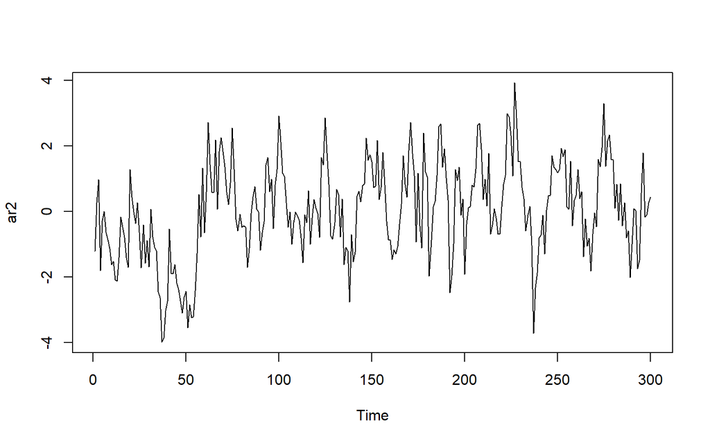

```r
ts.plot(ar2)
```

Berdasarkan plot time series tersebut terlihat bahwa data cenderung stasioner pada rataan

### Plot ACF

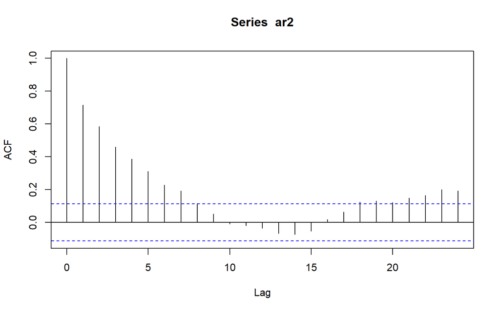

```r
acf(ar2)
```

Berdasarkan plot ACF tersebut terlihat bahwa plot ACF cenderung *tails off*.

### Plot PACF

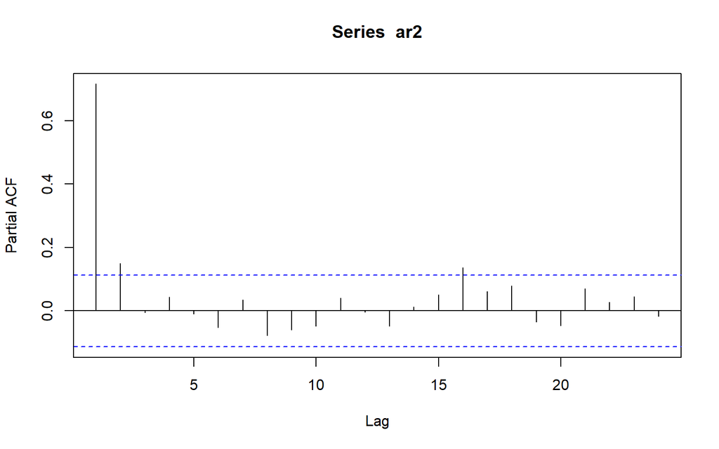

```r
pacf(ar2)
```

Berdasarkan plot PACF tersebut, terlihat bahwa plot PACF *cuts off* pada lag kedua.

### Plot EACF

```r
TSA::eacf(ar2)
```

```
## AR/MA
##   0 1 2 3 4 5 6 7 8 9 10 11 12 13
## 0 x x x x x x x o o o o  o  o  o
## 1 x o o o o o o o o o o  o  o  o
## 2 o o o o o o o o o o o  o  o  o
## 3 x x o o o o o o o o o  o  o  o
## 4 x x o o o o o o o o o  o  o  o
## 5 x x o x o o x o o o o  o  o  o
## 6 x x x x o o o o o o o  o  o  o
## 7 x x x o x x o o o o o  o  o  o
```

Berdasarkan pola segitiga nol pada plot EACF, terlihat bahwa segitiga nol berada pada ordo AR(2) dan ordo MA(0)

## Scatterplot Antar Lag

### Korelasi antara $Y_t$ dengan $Y_{t-1}$

```r
#Yt
yt_ar2 <- ar2[-1]
yt_ar2
```

```
##   [1]  0.277429242  0.981742648 -1.799340530 -0.274197047  0.009089263
##   [6] -0.625034738 -0.857331372 -1.118124633 -1.620566420 -1.511100836
##  [11] -2.078050147 -2.117499135 -1.409900780 -0.168956158 -0.476743729
##  [16] -0.783172602 -1.398130464 -1.692871432  1.289773370  0.440400618
##  [21] -0.012530914 -0.358733205  0.277716656 -0.626608560 -1.705965859
##  [26] -0.403548921 -1.566623355 -0.879159762 -1.688853153  0.082039017
##  [31] -0.772344201 -1.079204335 -1.195329068 -2.442598870 -2.627984511
##  [36] -3.982551678 -3.857865933 -3.019737161 -2.747339308 -0.528120821
##  [41] -1.882170996 -1.902074296 -1.608094349 -2.178802110 -2.379534243
##  [46] -2.732845736 -3.094315602 -2.617555067 -2.424490611 -3.541787576
##  [51] -2.837867835 -3.236181057 -3.200626105 -2.409858787 -1.281998796
##  [56]  0.524846317 -0.767330024  1.327213880 -0.647667612  0.598197434
##  [61]  2.718556265  1.444157230  0.596156288  0.579304834  2.185968123
##  [66]  0.070237292  1.840139450  2.263681974  1.836341674  1.377800070
##  [71]  0.600699632  0.209385897  0.873119442  2.548707762  1.295579357
```

[output cut: 45 more lines]

```r
#Yt-1
yt_1_ar2 <- ar2[-n]
yt_1_ar2
```

```
##   [1] -1.207065749  0.277429242  0.981742648 -1.799340530 -0.274197047
##   [6]  0.009089263 -0.625034738 -0.857331372 -1.118124633 -1.620566420
##  [11] -1.511100836 -2.078050147 -2.117499135 -1.409900780 -0.168956158
##  [16] -0.476743729 -0.783172602 -1.398130464 -1.692871432  1.289773370
##  [21]  0.440400618 -0.012530914 -0.358733205  0.277716656 -0.626608560
##  [26] -1.705965859 -0.403548921 -1.566623355 -0.879159762 -1.688853153
##  [31]  0.082039017 -0.772344201 -1.079204335 -1.195329068 -2.442598870
##  [36] -2.627984511 -3.982551678 -3.857865933 -3.019737161 -2.747339308
##  [41] -0.528120821 -1.882170996 -1.902074296 -1.608094349 -2.178802110
##  [46] -2.379534243 -2.732845736 -3.094315602 -2.617555067 -2.424490611
##  [51] -3.541787576 -2.837867835 -3.236181057 -3.200626105 -2.409858787
##  [56] -1.281998796  0.524846317 -0.767330024  1.327213880 -0.647667612
##  [61]  0.598197434  2.718556265  1.444157230  0.596156288  0.579304834
##  [66]  2.185968123  0.070237292  1.840139450  2.263681974  1.836341674
##  [71]  1.377800070  0.600699632  0.209385897  0.873119442  2.548707762
```

[output cut: 45 more lines]

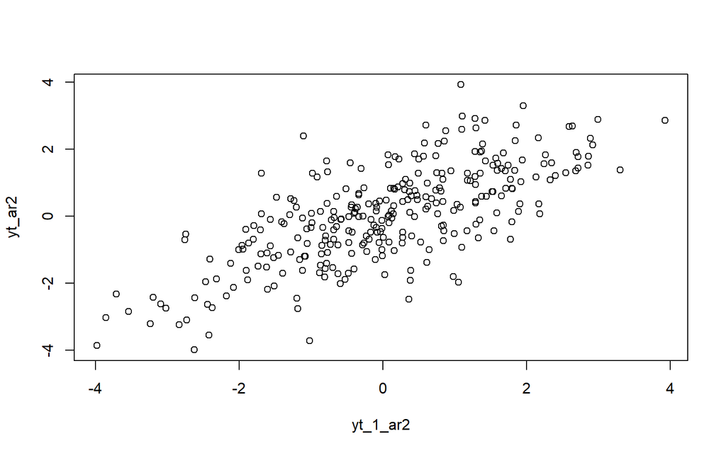

```r
plot(y=yt_ar2,x=yt_1_ar2)
```

Berdasarkan scatterplot tersebut, terlihat bahwa terdapat hubungan positif antara $Y_t$ dengan $Y_{t-1}$. Hal ini sesuai dengan teori yang ada

```r
cor(yt_ar2,yt_1_ar2)
```

```
## [1] 0.7165728
```

Korelasi antara $Y_t$ dengan $Y_{t-1}$ dari hasil simulasi mendekati perhitungan teoritis yaitu ρ1=0.625.
$$\rho_1 = \frac{\phi_1}{1-\phi_2}
= \frac{0.5}{1 - 0.2}
= \frac{0.5}{0.8}
= 0.625$$

### Korelasi antara $Y_t$ dengan $Y_{t-2}$

```r
#Yt
yt_ar2 <- ar2[-c(1,2)]
yt_ar2
```

```
##   [1]  0.981742648 -1.799340530 -0.274197047  0.009089263 -0.625034738
##   [6] -0.857331372 -1.118124633 -1.620566420 -1.511100836 -2.078050147
##  [11] -2.117499135 -1.409900780 -0.168956158 -0.476743729 -0.783172602
##  [16] -1.398130464 -1.692871432  1.289773370  0.440400618 -0.012530914
##  [21] -0.358733205  0.277716656 -0.626608560 -1.705965859 -0.403548921
##  [26] -1.566623355 -0.879159762 -1.688853153  0.082039017 -0.772344201
##  [31] -1.079204335 -1.195329068 -2.442598870 -2.627984511 -3.982551678
##  [36] -3.857865933 -3.019737161 -2.747339308 -0.528120821 -1.882170996
##  [41] -1.902074296 -1.608094349 -2.178802110 -2.379534243 -2.732845736
##  [46] -3.094315602 -2.617555067 -2.424490611 -3.541787576 -2.837867835
##  [51] -3.236181057 -3.200626105 -2.409858787 -1.281998796  0.524846317
##  [56] -0.767330024  1.327213880 -0.647667612  0.598197434  2.718556265
##  [61]  1.444157230  0.596156288  0.579304834  2.185968123  0.070237292
##  [66]  1.840139450  2.263681974  1.836341674  1.377800070  0.600699632
##  [71]  0.209385897  0.873119442  2.548707762  1.295579357 -0.233169716
```

[output cut: 45 more lines]

```r
#Yt-2
yt_2_ar2 <- ar2[-c(299,n)]
yt_2_ar2
```

```
##   [1] -1.207065749  0.277429242  0.981742648 -1.799340530 -0.274197047
##   [6]  0.009089263 -0.625034738 -0.857331372 -1.118124633 -1.620566420
##  [11] -1.511100836 -2.078050147 -2.117499135 -1.409900780 -0.168956158
##  [16] -0.476743729 -0.783172602 -1.398130464 -1.692871432  1.289773370
##  [21]  0.440400618 -0.012530914 -0.358733205  0.277716656 -0.626608560
##  [26] -1.705965859 -0.403548921 -1.566623355 -0.879159762 -1.688853153
##  [31]  0.082039017 -0.772344201 -1.079204335 -1.195329068 -2.442598870
##  [36] -2.627984511 -3.982551678 -3.857865933 -3.019737161 -2.747339308
##  [41] -0.528120821 -1.882170996 -1.902074296 -1.608094349 -2.178802110
##  [46] -2.379534243 -2.732845736 -3.094315602 -2.617555067 -2.424490611
##  [51] -3.541787576 -2.837867835 -3.236181057 -3.200626105 -2.409858787
##  [56] -1.281998796  0.524846317 -0.767330024  1.327213880 -0.647667612
##  [61]  0.598197434  2.718556265  1.444157230  0.596156288  0.579304834
##  [66]  2.185968123  0.070237292  1.840139450  2.263681974  1.836341674
##  [71]  1.377800070  0.600699632  0.209385897  0.873119442  2.548707762
```

[output cut: 45 more lines]

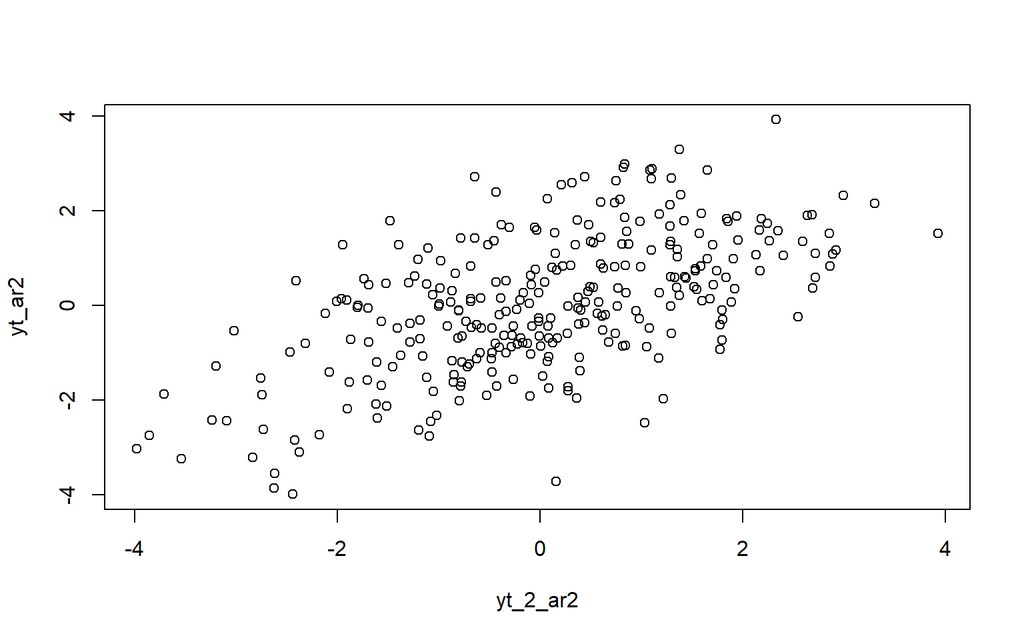

```r
plot(y=yt_ar2,x=yt_2_ar2)
```

Berdasarkan scatterplot tersebut, terlihat bahwa terdapat hubungan positif antara $Y_t$ dengan $Y_{t-2}$. Hal ini sesuai dengan teori yang ada

```r
cor(yt_ar2,yt_2_ar2)
```

```
## [1] 0.5856318
```

Korelasi antara $Y_t$ dengan $Y_{t-2}$ dari hasil simulasi mendekati perhitungan teoritis yaitu $\rho_2=\phi^2=0.5125$.
$$\rho_2 = \phi_1 \rho_1 + \phi_2\\
= 0.5 \times 0.625 + 0.2\\
= 0.3125 + 0.2
= 0.5125$$
### Korelasi antara $Y_t$ dengan $Y_{t-3}$

```r
#Yt
yt_ar2 <- ar2[-c(1,2,3)]
yt_ar2
```

```
##   [1] -1.799340530 -0.274197047  0.009089263 -0.625034738 -0.857331372
##   [6] -1.118124633 -1.620566420 -1.511100836 -2.078050147 -2.117499135
##  [11] -1.409900780 -0.168956158 -0.476743729 -0.783172602 -1.398130464
##  [16] -1.692871432  1.289773370  0.440400618 -0.012530914 -0.358733205
##  [21]  0.277716656 -0.626608560 -1.705965859 -0.403548921 -1.566623355
##  [26] -0.879159762 -1.688853153  0.082039017 -0.772344201 -1.079204335
##  [31] -1.195329068 -2.442598870 -2.627984511 -3.982551678 -3.857865933
##  [36] -3.019737161 -2.747339308 -0.528120821 -1.882170996 -1.902074296
##  [41] -1.608094349 -2.178802110 -2.379534243 -2.732845736 -3.094315602
##  [46] -2.617555067 -2.424490611 -3.541787576 -2.837867835 -3.236181057
##  [51] -3.200626105 -2.409858787 -1.281998796  0.524846317 -0.767330024
##  [56]  1.327213880 -0.647667612  0.598197434  2.718556265  1.444157230
##  [61]  0.596156288  0.579304834  2.185968123  0.070237292  1.840139450
##  [66]  2.263681974  1.836341674  1.377800070  0.600699632  0.209385897
##  [71]  0.873119442  2.548707762  1.295579357 -0.233169716 -0.581050764
```

[output cut: 45 more lines]

```r
#Yt-3
yt_3_ar2 <- ar2[-c(298,299,n)]
yt_3_ar2
```

```
##   [1] -1.207065749  0.277429242  0.981742648 -1.799340530 -0.274197047
##   [6]  0.009089263 -0.625034738 -0.857331372 -1.118124633 -1.620566420
##  [11] -1.511100836 -2.078050147 -2.117499135 -1.409900780 -0.168956158
##  [16] -0.476743729 -0.783172602 -1.398130464 -1.692871432  1.289773370
##  [21]  0.440400618 -0.012530914 -0.358733205  0.277716656 -0.626608560
##  [26] -1.705965859 -0.403548921 -1.566623355 -0.879159762 -1.688853153
##  [31]  0.082039017 -0.772344201 -1.079204335 -1.195329068 -2.442598870
##  [36] -2.627984511 -3.982551678 -3.857865933 -3.019737161 -2.747339308
##  [41] -0.528120821 -1.882170996 -1.902074296 -1.608094349 -2.178802110
##  [46] -2.379534243 -2.732845736 -3.094315602 -2.617555067 -2.424490611
##  [51] -3.541787576 -2.837867835 -3.236181057 -3.200626105 -2.409858787
##  [56] -1.281998796  0.524846317 -0.767330024  1.327213880 -0.647667612
##  [61]  0.598197434  2.718556265  1.444157230  0.596156288  0.579304834
##  [66]  2.185968123  0.070237292  1.840139450  2.263681974  1.836341674
##  [71]  1.377800070  0.600699632  0.209385897  0.873119442  2.548707762
```

[output cut: 45 more lines]

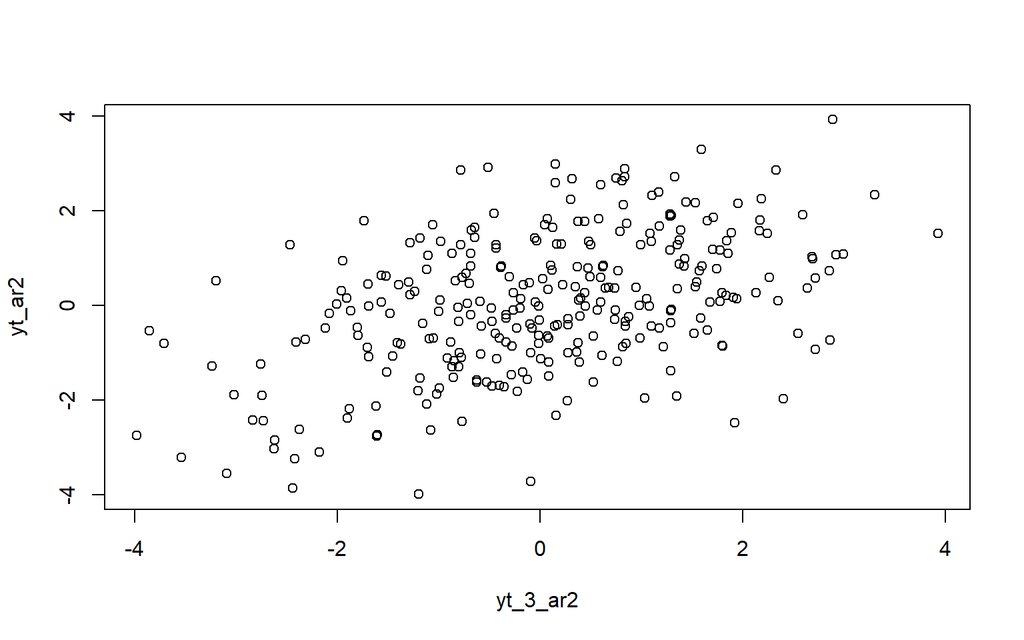

```r
plot(y=yt_ar2,x=yt_3_ar2)
```

Berdasarkan scatterplot tersebut, terlihat bahwa terdapat hubungan positif antara $Y_t$ dengan $Y_{t-3}$. Hal ini sesuai dengan teori yang ada

```r
cor(yt_ar2,yt_3_ar2)
```

```
## [1] 0.4609517
```

## Autokorelasi

```r
acf(ar2,lag.max = 10, plot=FALSE)$acf
```

```
## , , 1
##
##               [,1]
##  [1,]  1.000000000
##  [2,]  0.715577739
##  [3,]  0.584767799
##  [4,]  0.459945692
##  [5,]  0.386173207
##  [6,]  0.310563930
##  [7,]  0.228938747
##  [8,]  0.191524707
##  [9,]  0.116051367
## [10,]  0.052196288
## [11,] -0.009810566
```

```r
acf(ar2_sim,lag.max = 10, plot=FALSE)$acf
```

```
## , , 1
##
##              [,1]
##  [1,]  1.00000000
##  [2,]  0.71353067
##  [3,]  0.58283650
##  [4,]  0.44273546
##  [5,]  0.37336598
##  [6,]  0.29125223
##  [7,]  0.20684265
##  [8,]  0.16819639
##  [9,]  0.10266623
## [10,]  0.02853582
## [11,] -0.03269428
```

# Proses ARMA(2,2)

## Pembangkitan Proses ARMA(2) dengan $\theta_{1} = 0.4$, $\theta_{2} = 0.6$, $\phi_{1} = 0.5$, dan $\phi_{2} = 0.2$

```r
set.seed(1234)
n <- 300
wn <- rnorm(n)
arma22<- rep(0, n)
arma22[1:2] <- wn[1:2]
for(i in 3:n){
  arma22[i] <- 0.5*arma22[i-1] + 0.2*arma22[i-2] + wn[i] + 0.4*wn[i-1] + 0.6*wn[i-2]
}
arma22
```

```
##   [1] -1.20706575  0.27742924  0.36847490 -1.50574039 -0.53766490 -1.29969338
##   [7] -0.87222246 -1.16894421 -1.88686532 -2.62101924 -2.85976172 -3.67737093
##  [13] -3.87256190 -3.51682974 -2.01340200 -1.39787953 -1.08104743 -2.00187014
##  [19] -2.72540011 -0.22882482 -0.06137315  0.93599896 -0.10064445  0.12583632
##  [25] -0.73142392 -1.79048404 -1.46228520 -2.75191579 -1.74816209 -2.98066156
##  [31] -1.12112807 -1.75293957 -1.33899414 -2.09047491 -3.56829700 -4.32225497
##  [37] -6.49933032 -7.02769676 -6.95242937 -6.26996504 -3.43890746 -3.74182948
##  [43] -2.97182019 -3.49823048 -3.96328734 -4.21591391 -4.99194239 -5.61517573
##  [49] -5.49498973 -5.32810275 -6.08211743 -5.70927767 -6.49640107 -6.19781948
##  [55] -5.63181806 -4.16631812 -1.43386859 -1.32659086  1.33518960 -0.57718012
##  [61]  1.13545868  2.56923464  2.89049817  2.80495292  1.68426167  2.77538382
##  [67]  1.29220743  3.17981523  3.04188012  3.84589813  3.47054592  2.25362466
##  [73]  1.27634579  1.31729358  3.02358708  2.83893413  1.81428668  0.10302896
##  [79] -0.45121970 -0.85290753 -0.66635425 -0.93510416 -2.14779642 -2.08562341
##  [85] -1.51503473 -0.24121274  0.91556687  0.64537308  0.48311177 -1.14217407
```

[output cut: 35 more lines]

Nilai-nilai selanjutnya dapat dicari melalui *loop*. Bentuk loop dapat dilihat dari rumus ARMA(2,2) yang hendak dibangkitkan:
$$Y_t =
e_t+0.5Y_{t-1}+0.2Y_{t-2}+0.4e_{t-1}+0.6e_{t-2}$$

Pembangkitan ARMA(2,2) juga dapat dilakukan dengan fungsi `arima.sim` sebagai berikut.

```r
arma22_sim <- arima.sim(list(order=c(2,0,2), ar=c(0.5, 0.2), ma=c(0.4, 0.6)), n=n)
arma22_sim
```

```
## Time Series:
## Start = 1
## End = 300
## Frequency = 1
##   [1] -2.0296272586  0.1804874357 -1.0857429326  0.2019685297  0.5101006237
##   [6]  0.3116647978  1.1440157679  0.4568971792 -0.3804875233 -0.8758133113
##  [11]  0.3166261152  0.2548874061  0.2592079202 -0.3290331722 -0.2948120396
##  [16]  0.8417548499  2.0860897066  2.3426969416  3.4797265438  1.9702862497
##  [21] -0.2703838028 -1.6091794075 -2.9699033669 -4.6121759676 -3.5735246545
##  [26] -4.6576056483 -3.2455887429 -4.7021051669 -3.2231197169 -1.3940059863
##  [31] -1.1346987187 -0.1752041013  1.0623014400  2.1418761113  4.7392121372
##  [36]  4.1182608009  4.0004548088  2.2502034531  3.0645576995  0.9645314951
##  [41]  1.7489003118  0.3724604884  2.9537132225  1.8162605804  1.0974763535
##  [46]  0.1760865572 -0.5446303408 -0.9525033432 -0.8123258962 -1.3227469686
##  [51] -1.5334325506 -0.9672480418 -1.3288936550 -2.5250400524 -5.1130294931
```

[output cut: 49 more lines]

## Karakteristik ARMA(2,2)

### Plot Time Series

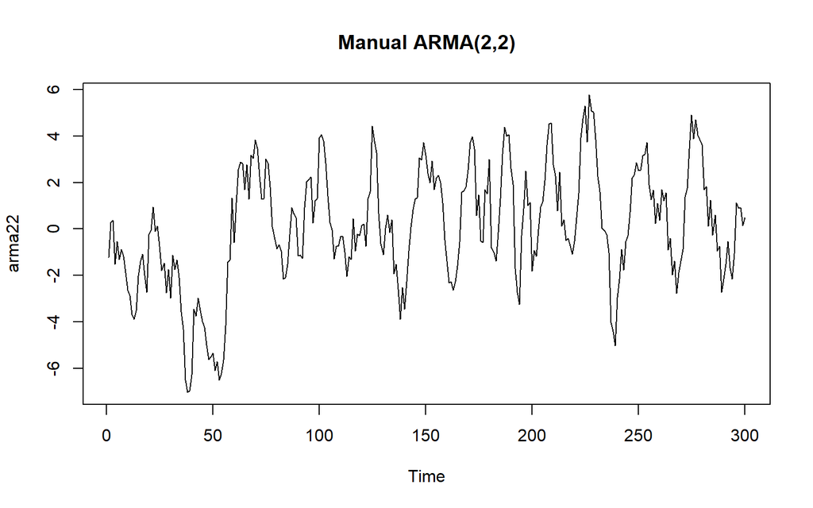

```r
ts.plot(arma22, main="Manual ARMA(2,2)")
```

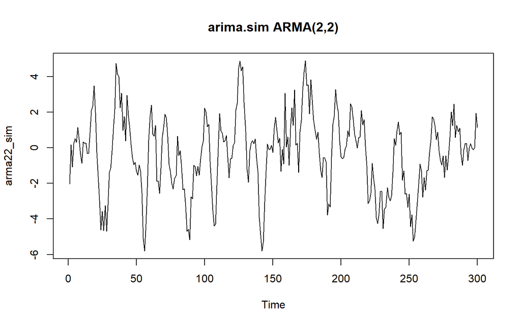

```r
ts.plot(arma22_sim, main="arima.sim ARMA(2,2)")
```

### Plot ACF

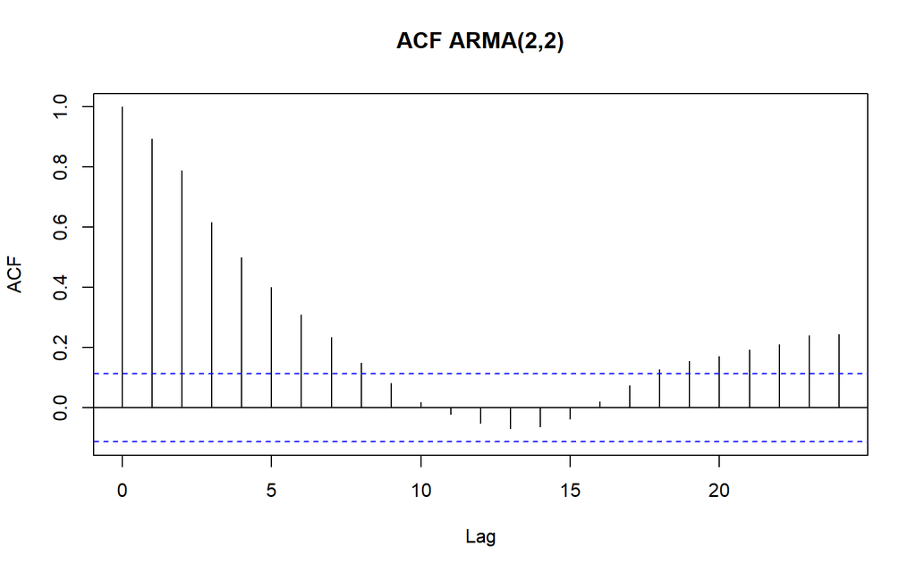

```r
acf(arma22, main="ACF ARMA(2,2)")
```

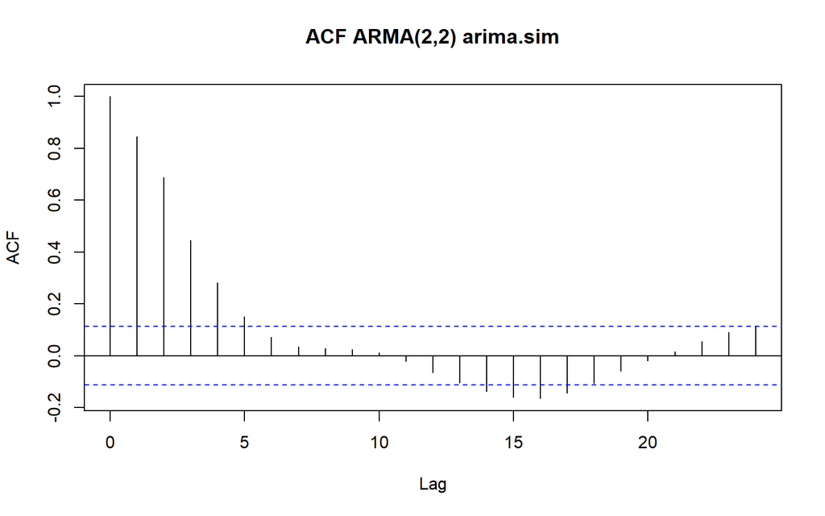

```r
acf(arma22_sim, main="ACF ARMA(2,2) arima.sim")
```

Berdasarkan plot ACF tersebut, terlihat bahwa model ARMA(2,2) hasil simulasi memiliki plot ACF yang *tails off*, sesuai dengan teori yang ada

### Plot PACF

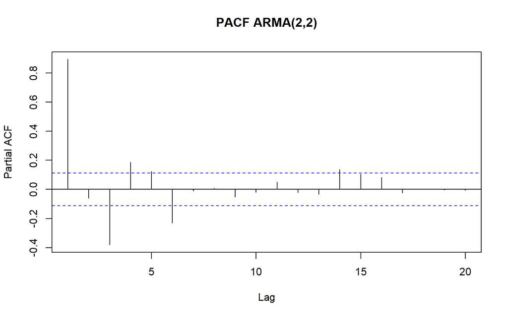

```r
pacf(arma22, lag.max=20, main="PACF ARMA(2,2)")
```

Berdasarkan plot PACF tersebut, terlihat bahwa model ARMA(2,2) hasil simulasi memiliki plot PACF yang *tails off*, sesuai dengan teori

### Plot EACF

```r
TSA::eacf(arma22)
```

```
## AR/MA
##   0 1 2 3 4 5 6 7 8 9 10 11 12 13
## 0 x x x x x x x x o o o  o  o  o
## 1 o x o o o o x o o o o  o  o  o
## 2 x x o o o o x o o o o  o  o  o
## 3 x x o x o o x o o o o  o  o  o
## 4 x x x x o o x o o o o  o  o  o
## 5 x x x x x x x o o o o  o  o  o
## 6 o o x o x x o o o o o  o  o  o
## 7 o o x o x x o x o o o  o  o  o
```

## Scatterplot Antar Lag

### Korelasi antara $Y_t$ dengan $Y_{t-1}$

```r
#Yt
yt_arma22 <- arma22[-1]
yt_arma22
```

```
##   [1]  0.27742924  0.36847490 -1.50574039 -0.53766490 -1.29969338 -0.87222246
##   [7] -1.16894421 -1.88686532 -2.62101924 -2.85976172 -3.67737093 -3.87256190
##  [13] -3.51682974 -2.01340200 -1.39787953 -1.08104743 -2.00187014 -2.72540011
##  [19] -0.22882482 -0.06137315  0.93599896 -0.10064445  0.12583632 -0.73142392
##  [25] -1.79048404 -1.46228520 -2.75191579 -1.74816209 -2.98066156 -1.12112807
##  [31] -1.75293957 -1.33899414 -2.09047491 -3.56829700 -4.32225497 -6.49933032
##  [37] -7.02769676 -6.95242937 -6.26996504 -3.43890746 -3.74182948 -2.97182019
##  [43] -3.49823048 -3.96328734 -4.21591391 -4.99194239 -5.61517573 -5.49498973
##  [49] -5.32810275 -6.08211743 -5.70927767 -6.49640107 -6.19781948 -5.63181806
##  [55] -4.16631812 -1.43386859 -1.32659086  1.33518960 -0.57718012  1.13545868
##  [61]  2.56923464  2.89049817  2.80495292  1.68426167  2.77538382  1.29220743
##  [67]  3.17981523  3.04188012  3.84589813  3.47054592  2.25362466  1.27634579
##  [73]  1.31729358  3.02358708  2.83893413  1.81428668  0.10302896 -0.45121970
##  [79] -0.85290753 -0.66635425 -0.93510416 -2.14779642 -2.08562341 -1.51503473
##  [85] -0.24121274  0.91556687  0.64537308  0.48311177 -1.14217407 -1.12039092
```

[output cut: 35 more lines]

```r
#Yt-1
yt_1_arma22 <- arma22[-n]
yt_1_arma22
```

```
##   [1] -1.20706575  0.27742924  0.36847490 -1.50574039 -0.53766490 -1.29969338
##   [7] -0.87222246 -1.16894421 -1.88686532 -2.62101924 -2.85976172 -3.67737093
##  [13] -3.87256190 -3.51682974 -2.01340200 -1.39787953 -1.08104743 -2.00187014
##  [19] -2.72540011 -0.22882482 -0.06137315  0.93599896 -0.10064445  0.12583632
##  [25] -0.73142392 -1.79048404 -1.46228520 -2.75191579 -1.74816209 -2.98066156
##  [31] -1.12112807 -1.75293957 -1.33899414 -2.09047491 -3.56829700 -4.32225497
##  [37] -6.49933032 -7.02769676 -6.95242937 -6.26996504 -3.43890746 -3.74182948
##  [43] -2.97182019 -3.49823048 -3.96328734 -4.21591391 -4.99194239 -5.61517573
##  [49] -5.49498973 -5.32810275 -6.08211743 -5.70927767 -6.49640107 -6.19781948
##  [55] -5.63181806 -4.16631812 -1.43386859 -1.32659086  1.33518960 -0.57718012
##  [61]  1.13545868  2.56923464  2.89049817  2.80495292  1.68426167  2.77538382
##  [67]  1.29220743  3.17981523  3.04188012  3.84589813  3.47054592  2.25362466
##  [73]  1.27634579  1.31729358  3.02358708  2.83893413  1.81428668  0.10302896
##  [79] -0.45121970 -0.85290753 -0.66635425 -0.93510416 -2.14779642 -2.08562341
##  [85] -1.51503473 -0.24121274  0.91556687  0.64537308  0.48311177 -1.14217407
```

[output cut: 35 more lines]

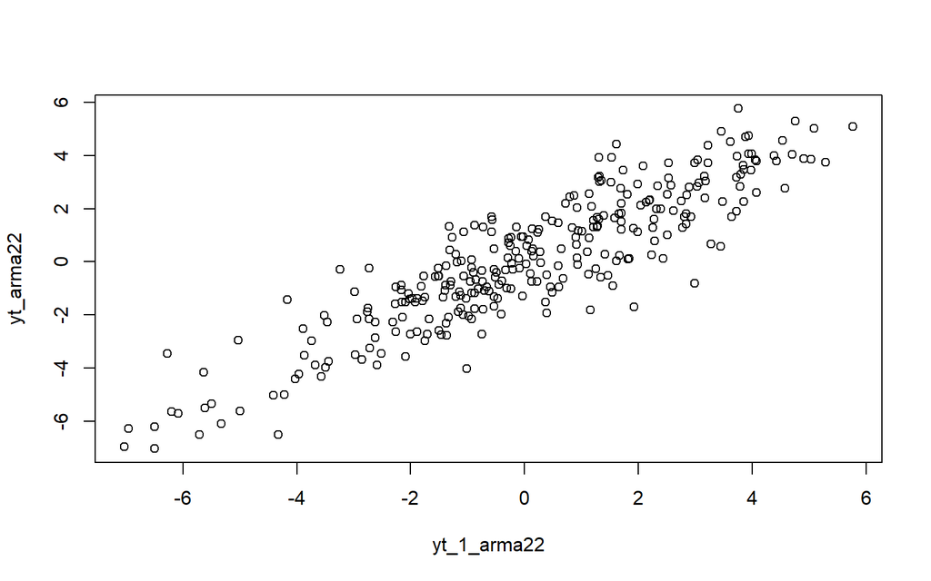

```r
plot(y=yt_arma22,x=yt_1_arma22)
```

Berdasarkan scatterplot tersebut, terlihat bahwa terdapat hubungan positif antara $Y_t$ dengan $Y_{t-1}$.

```r
cor(yt_arma22,yt_1_arma22)
```

```
## [1] 0.8946787
```

### Korelasi antara $Y_t$ dengan $Y_{t-2}$

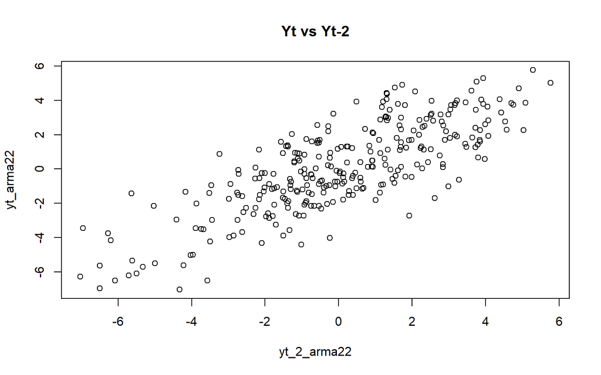

```r
yt_arma22 <- arma22[-c(1,2)]
yt_2_arma22 <- arma22[-c(299, n)]
plot(y=yt_arma22,x=yt_2_arma22, main="Yt vs Yt-2")
```

Berdasarkan scatterplot tersebut, terlihat bahwa terdapat hubungan positif antara $Y_t$ dengan $Y_{t-2}$.

```r
cor(yt_arma22,yt_2_arma22)
```

```
## [1] 0.78822
```

### Korelasi antara $Y_t$ dengan $Y_{t-3}$

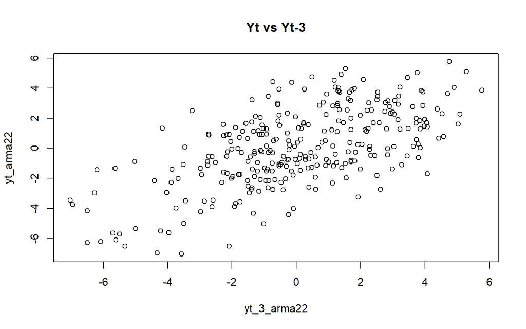

```r
yt_arma22 <- arma22[-c(1,2,3)]
yt_3_arma22 <- arma22[-c(298,299, n)]
plot(y=yt_arma22,x=yt_3_arma22, main="Yt vs Yt-3")
```

Berdasarkan scatterplot tersebut, terlihat bahwa terdapat hubungan positif antara $Y_t$ dengan $Y_{t-3}$.

```r
cor(yt_arma22,yt_3_arma22)
```

```
## [1] 0.6177423
```

## Autokorelasi

```r
acf(arma22,lag.max = 10, plot=FALSE)$acf
```

```
## , , 1
##
##             [,1]
##  [1,] 1.00000000
##  [2,] 0.89425596
##  [3,] 0.78783999
##  [4,] 0.61732077
##  [5,] 0.49993844
##  [6,] 0.40089929
##  [7,] 0.31016176
##  [8,] 0.23367252
##  [9,] 0.14898757
## [10,] 0.08067289
## [11,] 0.01773312
```

```r
acf(arma22_sim,lag.max = 10, plot=FALSE)$acf
```

```
## , , 1
##
##             [,1]
##  [1,] 1.00000000
##  [2,] 0.84539224
##  [3,] 0.68716196
##  [4,] 0.44503732
##  [5,] 0.28137061
##  [6,] 0.15115535
##  [7,] 0.07236801
##  [8,] 0.03531025
##  [9,] 0.02905171
## [10,] 0.02465017
## [11,] 0.01138468
```